# US cats and dogs

Anna Reynolds

11 September 2018

## Cat and dog ownership in the US

This weeks #TidyTuesday data set contains data on the proportion of households that own cats and dogs in the US. The data is from the American Veterinary Medical Association via data.world. It was reported on in a [Washington Post article](https://www.washingtonpost.com/news/wonk/wp/2014/07/28/where-cats-are-more-popular-than-dogs-in-the-u-s-and-all-over-the-world/?noredirect=on&utm_term=.e27b64bffdee)

It concludes that cats are more popular than dogs.

### Import the data

```r
pets <- read_tsv("cats_dogs.csv")
head(pets)
```

```
## # A tibble: 6 x 13
##      X1 state       n_households percent_pet_households n_pet_households
##   <int> <chr>              <int>                  <dbl>            <int>
## 1     1 Alabama             1828                   59.5             1088
## 2     2 Arizona             2515                   59.5             1497
## 3     3 Arkansas            1148                   62.4              716
## 4     4 California         12974                   52.9             6865
## 5     5 Colorado            1986                   61.3             1217
## 6     6 Connecticut         1337                   54.4              728
## # ... with 8 more variables: percent_dog_owners <dbl>,
## #   n_dog_households <int>, avg_dogs_per_household <dbl>,
## #   dog_population <int>, percent_cat_owners <dbl>,
## #   n_cat_households <int>, avg_cats_per_household <dbl>,
## #   cat_population <int>
```

### Which states have the highest proportion of households with pets?

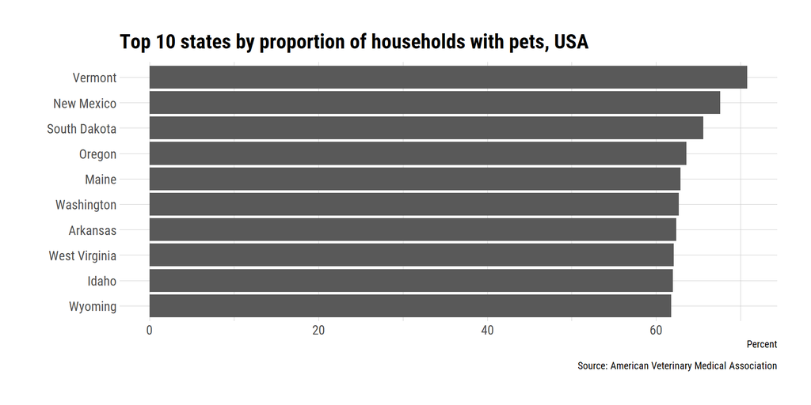

```r
pet_10 <- pets  %>% top_n(percent_pet_households,n=10)
bar1 <- ggplot(pet_10, aes(x = reorder(state, percent_pet_households), y = percent_pet_households))+ geom_bar(stat = "identity") + coord_flip() + theme_ipsum_rc() + labs(x=" ", y="Percent",
       title="Top 10 states by proportion of households with pets, USA",
       caption="Source: American Veterinary Medical Association")
bar1
```

Vermont has the highest proportion of households with pets.

### What is the ratio of cats to dogs in each state?

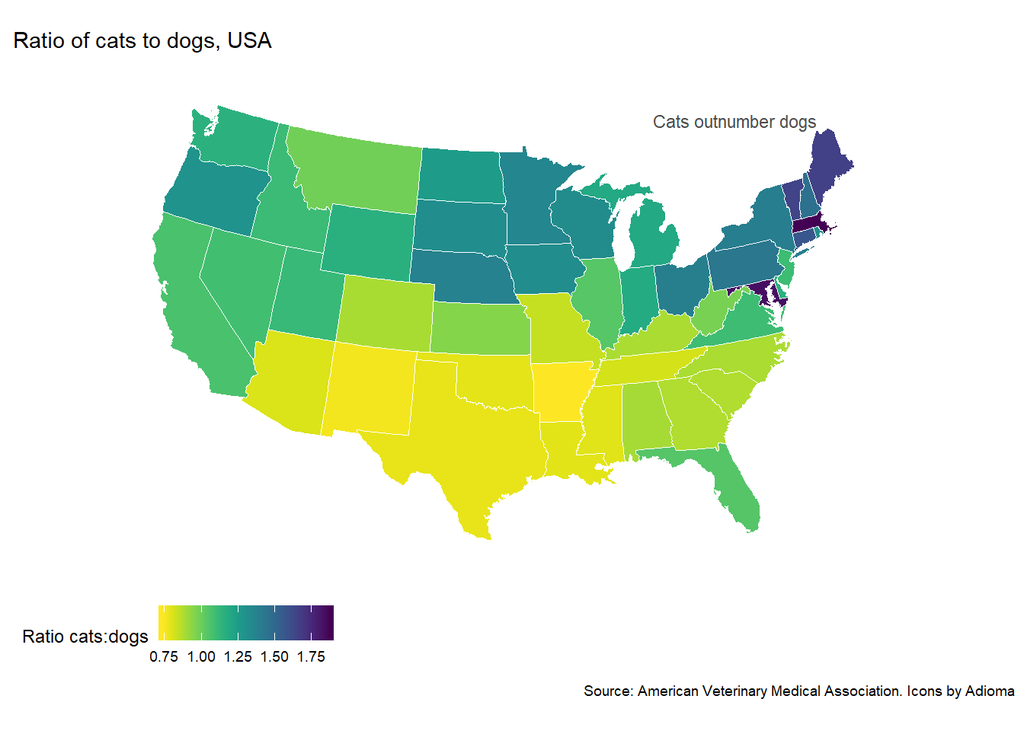

```r
cats_dogs <- mutate(pets, ratio = cat_population/dog_population)

states <- map_data("state") #Get US state geo information
data <- cats_dogs %>% mutate(region = tolower(state))
# Join the values to the map using region
us_map <- left_join(states, data)
#generate the map
map1 <- ggplot() + geom_map(aes(x = long, y = lat, map_id = region), data = us_map,
           map = us_map, fill = "#ffffff", color = "#ffffff", size = 0.15) + geom_map(aes(fill = ratio, map_id = region),
           map = us_map, data = us_map,
           color = "#ffffff", size = 0.15) +
  viridis::scale_fill_viridis(name="Ratio cats:dogs", direction=-1) +
  coord_map('albers', lat0 = 39, lat1 = 45) +
  ggthemes::theme_map() +
  theme(legend.position="bottom") +
  labs(title = "Ratio of cats to dogs, USA",
    caption = "Source: American Veterinary Medical Association. Icons by Adioma") + annotate("text", x = -75.85, y = 49.325, label = "Cats outnumber dogs", size=3, colour="gray30")
map1
```

Cats are more popular than dogs in the Northern states but particularly in the North-Eastern states. This may be due to less space in highly urban areas making it easier for people to own cats.

### Add some images using the magick package

```r
library(magick)
library(grid)

#Import cat and dog icons
cat <- image_read("cat.png")
dog <- image_read("big-dog.png")
#Resize images
cat2 <- image_scale(cat, "x50")
dog2 <- image_scale(dog, "x50")
print(cat2)
```

```
##   format width height colorspace matte filesize density
## 1    PNG    50     50       sRGB  TRUE        0   19x19
```

```r
#Add images to map

fig <- image_graph(width = 800, height = 800, res = 96)
map1
dev.off()
```

```
##   format width height colorspace matte filesize density
## 1    PNG   800    800       sRGB  TRUE        0   72x72
```

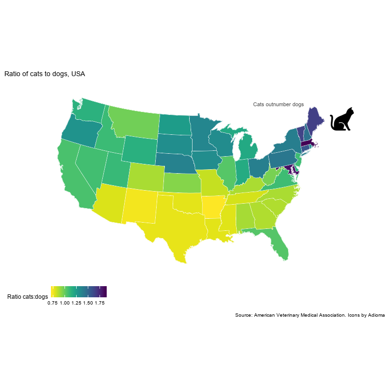

```r
# Combine
out <- image_composite(fig, cat2, offset = "+680+220")
print(out)
```

```
##   format width height colorspace matte filesize density
## 1    PNG   800    800       sRGB  TRUE        0   72x72
```

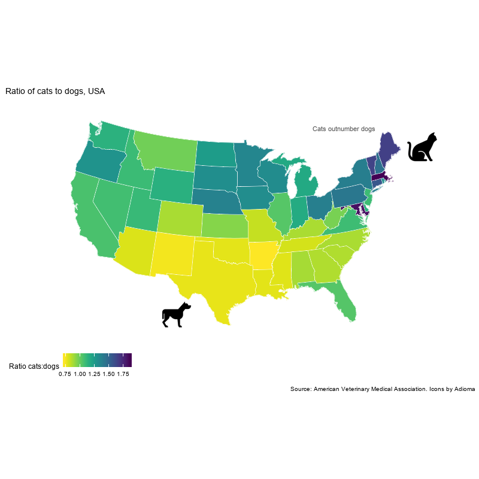

```r
out2 <- image_composite(out, dog2, offset = "+270+500")
print(out2)
```

```r
#Save image
image_write(out2, "US_cats.png")
```

### Is there a relationship between states with higher % cat owners and % urban population?

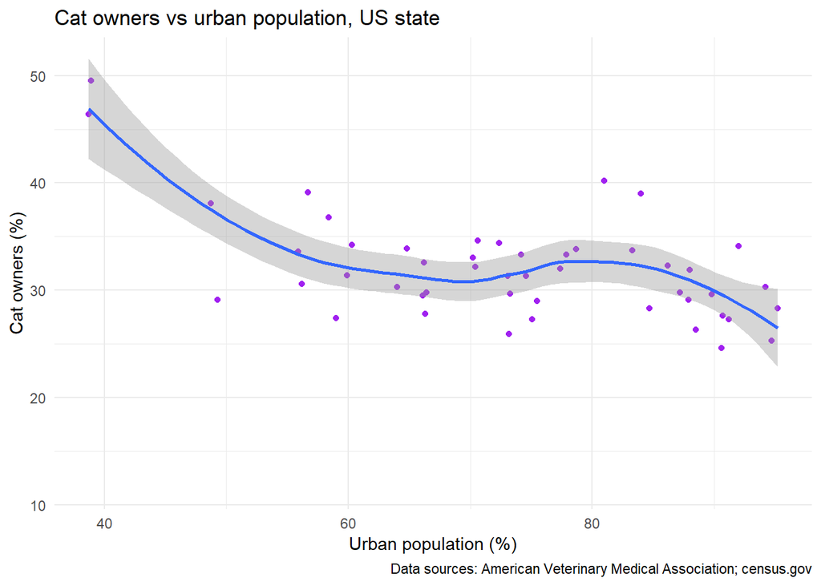

```r
#Import data on US urban population by state
urban <-  readxl::read_excel('us_urban_state_percentage_wikipedia.xlsx') %>% rename(state = 'State/Territory')
data_urban <- left_join(data, urban) %>% rename(urban_percent = '2010')
#Generate a scatterplot
sp <- ggplot (data_urban, aes ( x = urban_percent*100 , y = percent_cat_owners, label=state)) + geom_point (size = 1.5, color = "purple") + theme_minimal() + geom_smooth() + labs(x="Urban population (%)", y="Cat owners (%)", title="Cat owners vs urban population, US state", caption="Data sources: American Veterinary Medical Association; census.gov")
sp
```

It appears as though the proportion of households with cats decreases as the proportion of the urban population increases.

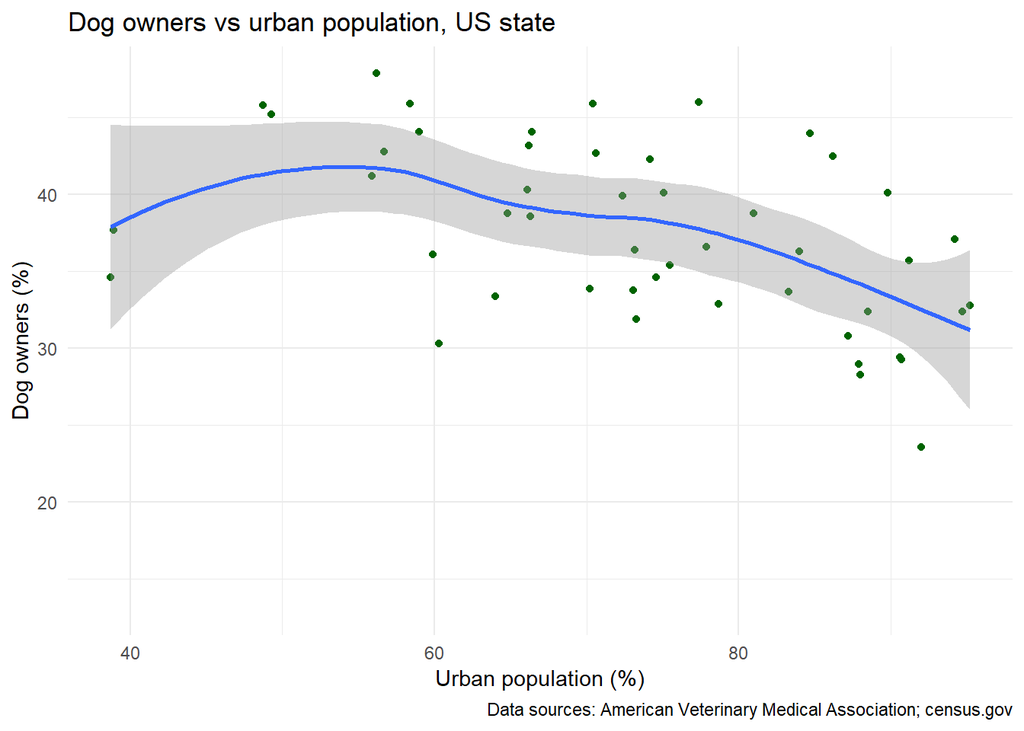

```r
sp2 <- ggplot (data_urban, aes ( x = urban_percent*100 , y = percent_dog_owners, label=state)) + geom_point (size = 1.5, color = "dark green") + theme_minimal() + geom_smooth() + labs(x="Urban population (%)", y="Dog owners (%)", title="Dog owners vs urban population, US state", caption="Data sources: American Veterinary Medical Association; census.gov")
sp2
```

A similar relationship was found for households with dogs.

## International comparisons

The US has a similar pet ownership rate to Australia with 65% of homes having a pet. More than 62% of Australian households own a pet. Of these, 38% are dog owners and 29% are cat owners. This is more than the UK, in which just 40% of homes have a pet. [Australian Pet Ownership Statistics, Pet Industry Association](https://piaa.net.au/australian-pet-ownership-statistics/)

## Package citation(s)

Jeroen Ooms (2018). magick: Advanced Graphics and Image-Processing in R. R package version 1.9. https://CRAN.R-project.org/package=magick

R Core Team (2018). R: A language and environment for statistical computing. R Foundation for Statistical Computing, Vienna, Austria. URL https://www.R-project.org/.

Bob Rudis (2018). hrbrthemes: Additional Themes, Theme Components and Utilities for ‘ggplot2’. R package version 0.5.0. https://CRAN.R-project.org/package=hrbrthemes

Hadley Wickham (2017). tidyverse: Easily Install and Load the ‘Tidyverse’. R package version 1.2.1. https://CRAN.R-project.org/package=tidyverse

Yihui Xie (2018). knitr: A General-Purpose Package for Dynamic Report Generation in R. R package version 1.20.